# R Beginners Course 2026

Introduction to R and Basic Programming Concepts

Dr. Debasish Mukherjee, Dr. Ulrike Goebel, Dr. Ali Abdallah

Bioinformatics Core Facility CECAD

2025-05-13

Session 5 :: Visualization

## R Plots (base) – some preparations

First we will **pre-compute the mean values of each flower trait in each species** for later use.

#### Step 1: Split the full table into species-specific tables

```r
species_tables <-
    split(iris[,-5],  ## what to split
          iris[, 5])  ## split by what
```

```r
class(species_tables)
```

```
[1] "list"
```

```r
names(species_tables)
```

```
[1] "setosa"     "versicolor" "virginica"
```

```r
head(species_tables[["setosa"]],n=3)
```

```
  Sepal.Length Sepal.Width Petal.Length Petal.Width
1          5.1         3.5          1.4         0.2
2          4.9         3.0          1.4         0.2
3          4.7         3.2          1.3         0.2
```

## R Plots (base) – some preparations

#### Step 2: Compute the means and assemble them into a matrix

```r
species_means <-
    rbind(setosa =
            colMeans( ## return table column means as a vector
                species_tables[["setosa"]]
                ),
          versicolor =
            colMeans(species_tables[["versicolor"]]),
          virginica =
            colMeans(species_tables[["virginica"]])
    )

species_means
```

```
           Sepal.Length Sepal.Width Petal.Length Petal.Width
setosa            5.006       3.428        1.462       0.246
versicolor        5.936       2.770        4.260       1.326
virginica         6.588       2.974        5.552       2.026
```

## R Plots (base) – some preparations

Finally we define **our own coloring scheme**:

```r
## These colors are supposed to be easy to
## discriminate for sight-impaired people.
species_colors = setNames( ## makes a named vector
                    palette()[1:3],  rownames(species_means)
                 )
species_colors
```

```
    setosa versicolor  virginica
   "black"  "#DF536B"  "#61D04F"
```

```r
## colors reflecting the organ type:
trait_colors <-
    c(Petal.Length = "orange2",Petal.Width = "yellow2",
      Sepal.Length = "blue3",Sepal.Width = "lightblue"
    )
trait_colors
```

```
Petal.Length  Petal.Width Sepal.Length  Sepal.Width
   "orange2"    "yellow2"      "blue3"  "lightblue"
```

## R Plots (base)

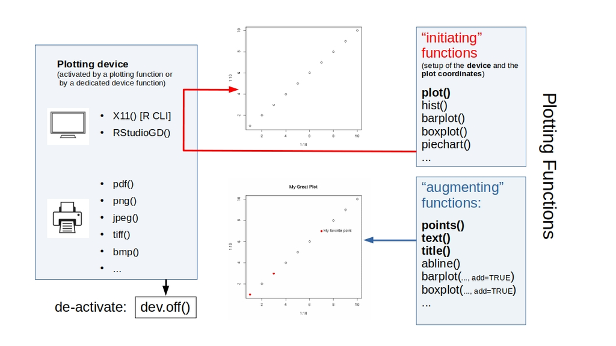

## R Plots (base) – **`barplot()`**

Barplots represent sign and absolute value of **numbers** by the direction and length of **bars**.

If called with a matrix as first argument, the function produces **one plot for each column**:

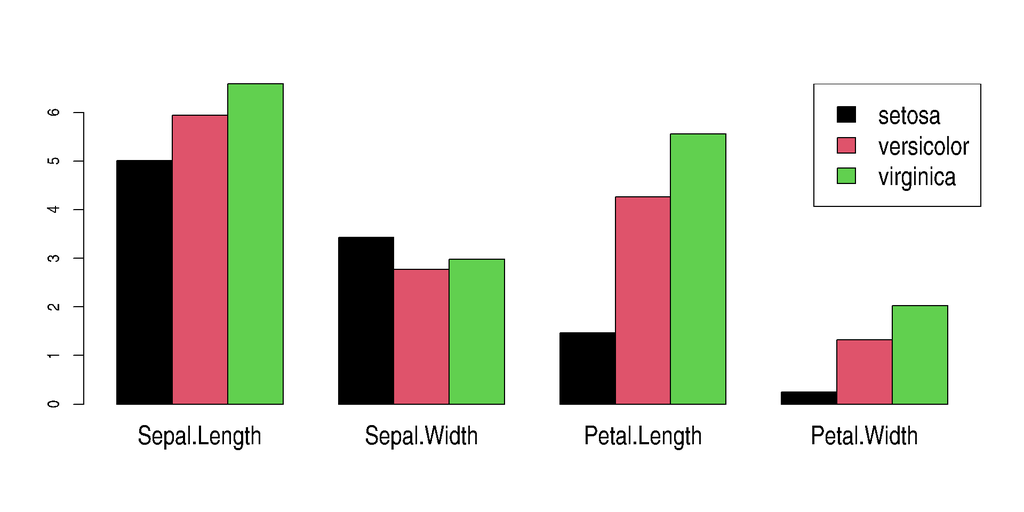

```r
barplot(## one plot per column == trait,
        ## one bar == species mean!
        species_means,

        ## do not stack the bars
        beside=TRUE,

        ## larger group labels
        cex.names=1.5,

        col=species_colors,
        )

## add a legend (plot "augmentation"!)
legend("topright",
       rownames(species_means),
       fill=species_colors,
       cex=1.5)
```

## R Plots (base) – **`barplot()`**

If we want to plot trait means per species, we must **change the rows of matrix species_means (= the species) into columns**, because barplot() reads a matrix by column.

This is done by the **`t()`** function (**`"transpose"`**):

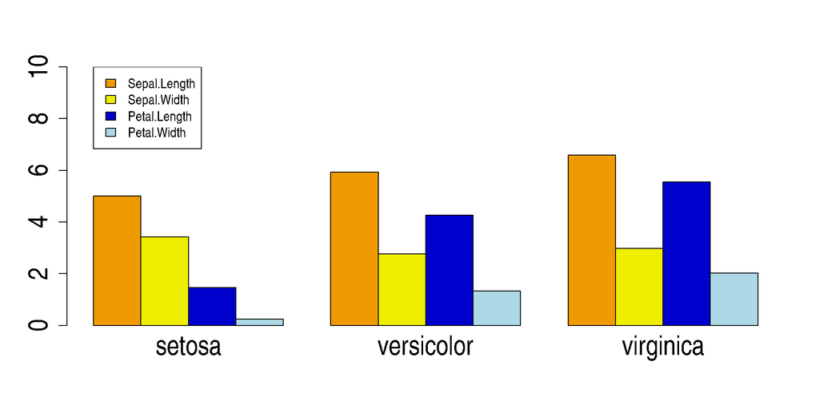

```r
m <-  t(species_means) ## TRANSPOSE

barplot(## one plot per column == species,
        ## one bar == trait mean!
        m,

        ## do not stack the bars
        beside=TRUE,

        ## larger group labels
        cex.names=2,

        col=trait_colors,

        ## increase y limit to fit the legend
        ylim = c(0,10),
        cex = 2
        )

## add a legend (plot "augmentation"!)
legend(x=1,y=10, ##"topright",
       rownames(m),
       fill=trait_colors)
```

## R Plots (base) – **`pie()`**

Piecharts are a quick-and-dirty alternative for representing numbers.

The **`pie()`** function can only represent one set of numbers at a time. In addition, comparing angles on a piechart is visually not as easy as comparing bar heights.

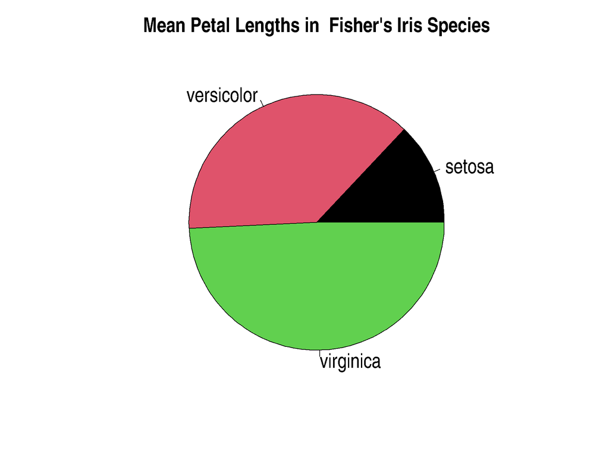

```r
pie(species_means[,"Petal.Length"],
    labels = rownames(species_means),
    main = paste("Mean Petal Lengths in ",
                 "Fisher's Iris Species"),
    col=species_colors,

    cex=2, ## larger text annotation
    cex.main = 2 ## larger title
)
```

## R Plots (base) – **`pie()`**

Piecharts are a quick-and-dirty alternative for representing numbers.

The **`pie()`** function can only represent one set of numbers at a time. In addition, comparing angles on a piechart is visually not as easy as comparing bar heights.

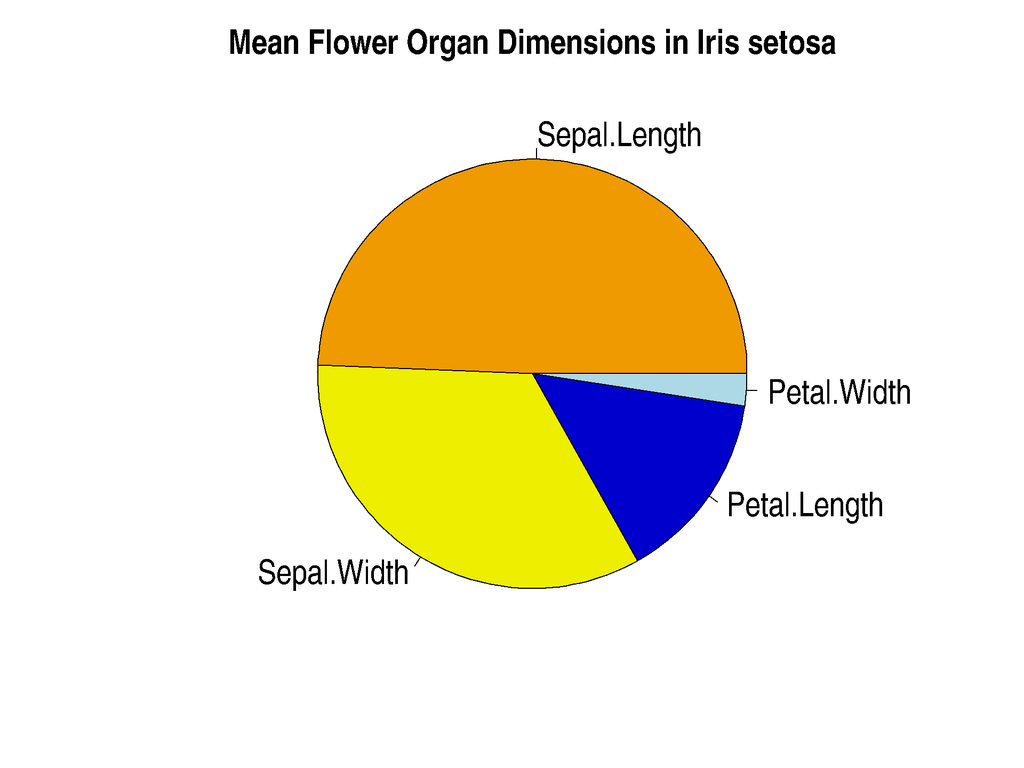

```r
pie(species_means["setosa",],
    labels = colnames(species_means),
    main = paste("Mean Flower Organ Dimensions",
                 "in Iris setosa"),
    col=trait_colors,

    cex=2, ## larger text annotation
    cex.main = 2 ## larger title
)
```

## R Plots (base) – **`plot()`**

The **`plot()`** function is an **extremely versatile workhorse for x/y plots**.

As an “initializing” function, it may be called to just create an empty canvas, to be filled later:

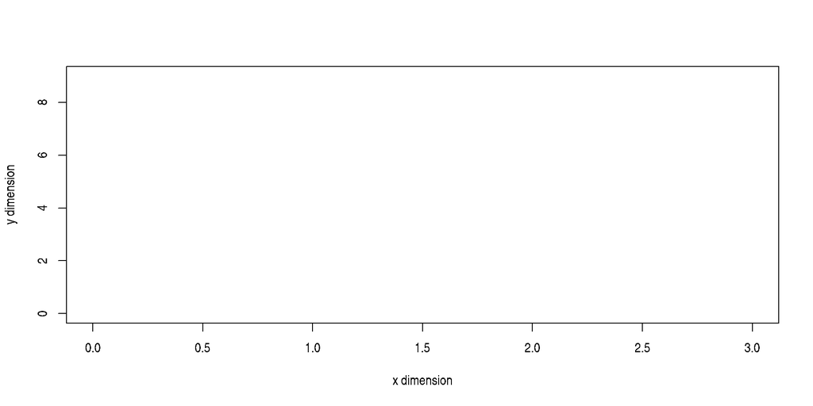

```r
## (see par() for graphical parameters!)
plot(x=NULL,y=NULL,

     ## Note that if you start empty,
     ## you have to set the canvas
     ## dimensions yourself!

     xlim=c(0,3),
     ylim=c(0,9),
     xlab = "x dimension",
     ylab = "y dimension"

)
```

## R Plots (base) – **`plot()`**

Or it is called with an initial set of data, with the option to extend the plot later:

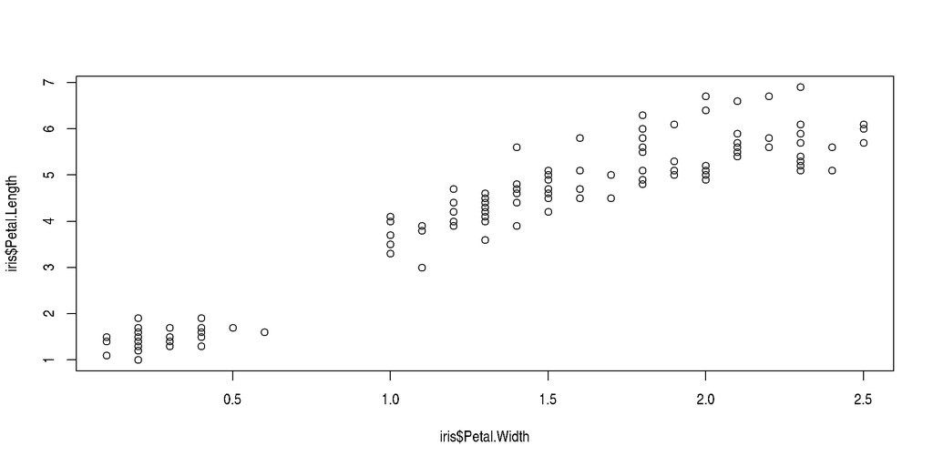

```r
plot(x=iris$Petal.Width,
     y=iris$Petal.Length
)
```

## R Plots (base) – **`plot()`**

There is more than one way to relate x/y dimensions to data!

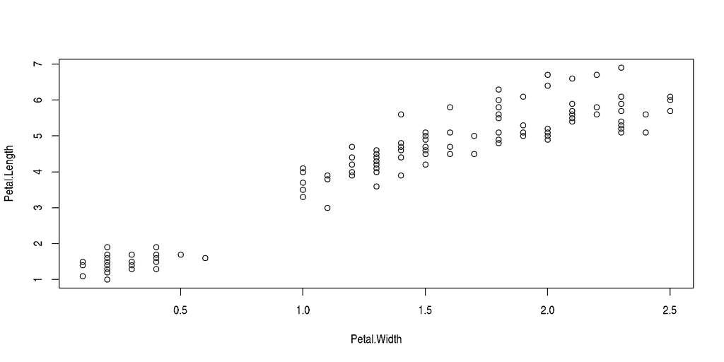

```r
## Initialize a new plot,
## using formula notation to specify x and y:
plot(Petal.Length ~ Petal.Width,
     data = iris)
```

## R Plots (base) – **`plot()`**

Add a grid:

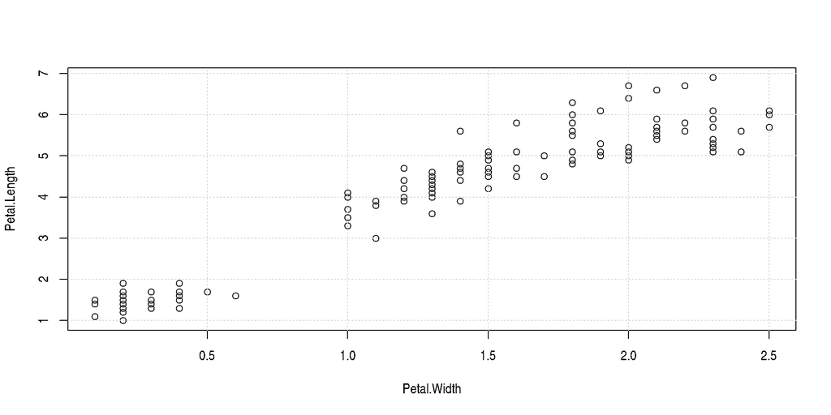

```r
grid()
```

## R Plots (base) – **`plot()`**

Overplot some points with color, in order to identify a group in your data:

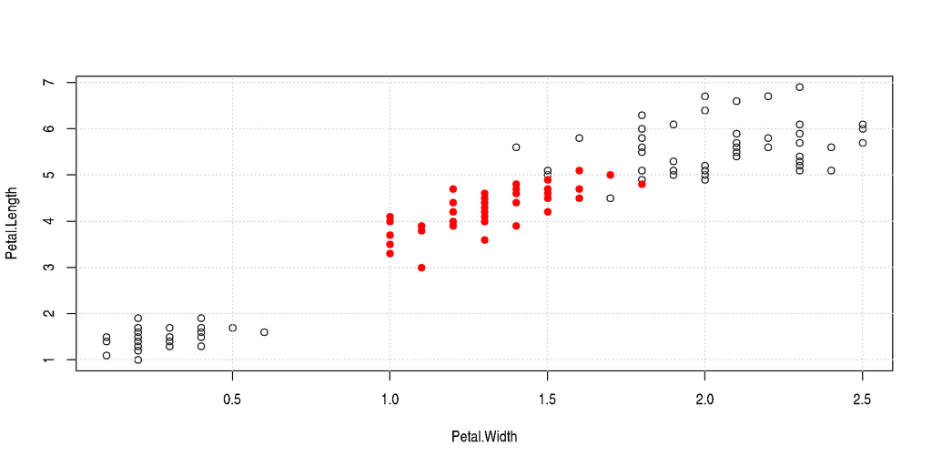

```r
points(Petal.Length ~ Petal.Width,

       data=subset(iris,
                Species == "versicolor"
            ),

       pch=21, # symbol code 21: bullet with
               # separate interior color (bg)
               # and border color (col)
               ## See points()!

       ## Set color manually:
       col= "red",
       bg = "red"
)
```

## R Plots (base) – **`plot()`**

Color all points by species, using our named vector **species_colors**:

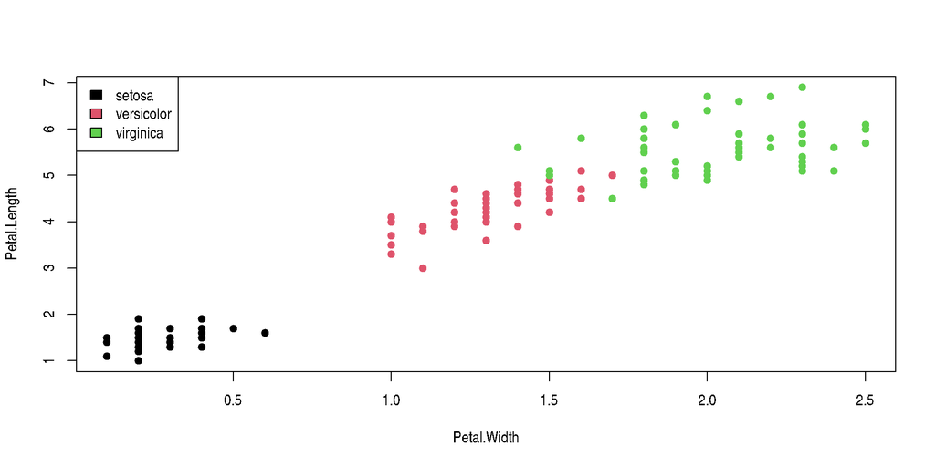

```r
plot(Petal.Length ~ Petal.Width,
     data=iris,
     pch=21,

     ## index the "species_colors" vector
     ## by species names:
     col=species_colors[Species],
     bg =species_colors[Species]
     )

legend("topleft",
       rownames(species_means),
       fill=species_colors)
```

## R Plots (base) – **`plot()`**

Points **with adjacent positions in the input** can be connected by lines, using different line styles. **A typical use case is a line graph**, with x as a running number or ID.

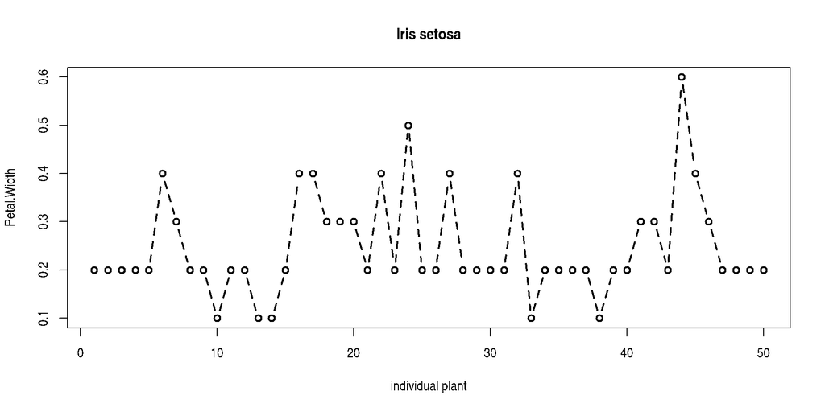

```r
## See par() for line-related parameters!

## Make a new data.frame,
## containing only setosa:
df <- subset(iris, Species=="setosa")

plot(
     # x is now the row number in df
     x=1:nrow(df),
     xlab="individual plant",

     y=df$Petal.Width,
     ylab="Petal.Width",

     ## show both points and
     ## connecting lines:
     type="b",

     ## line width:
     lwd = 2,
     ## line style = dashed:
     lty=2,

     main="Iris setosa"
)
```

## R Plots (base) – **`plot()`**

It can make sense to connect **some** points in a general scatterplot by lines.  
The augmenting function **lines()** can do this.

Here, we want to **connect the (x,y) means of our three species**:

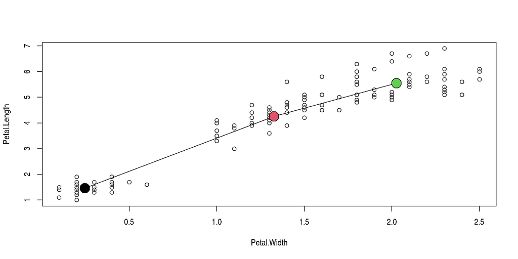

```r
## Initialize a plain x/y plot:
plot(Petal.Length ~ Petal.Width,
     data=iris)

## Add colored mean points, connected by lines
lines(x=species_means[,"Petal.Width"],
      y=species_means[,"Petal.Length"],
      type="b", # show both points and lines
      pch=21,
      bg=species_colors,
      cex=2.5
)
```

## R Plots (base) – **`plot()`**

**Annotate individual points**:

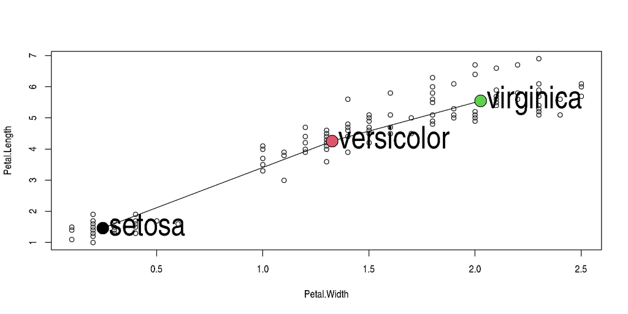

```r
text(x=species_means[,"Petal.Width"],
     y=species_means[,"Petal.Length"],

     labels=rownames(species_means),

     pos=4, ## put labels to the right of points
            ## (see ?text)
     cex=3  ## expansion factor for the text
)
```

## R Plots (base) – **`plot()`**

Function **abline()** adds indicator lines to a plot.

**Regression line**:

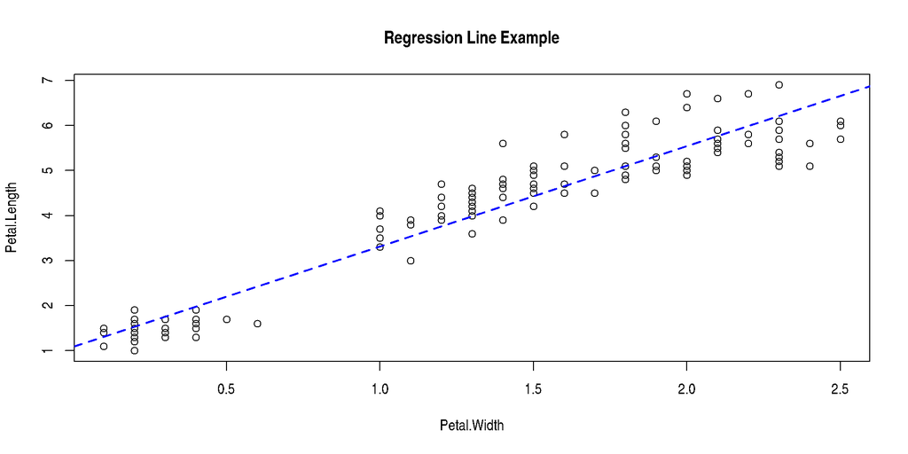

```r
## Initialize a plain x/y plot:
plot(Petal.Length ~ Petal.Width,
     data=iris,
     ## Put a title:
     main = "Regression Line Example")

## Mark the linear regression line:
abline(lm(Petal.Length ~ Petal.Width,
          data=iris
       ),
       lty=2, lwd=2,col="blue"
       )
```

## R Plots (base) – **`plot()`**

Function **abline()** adds indicator lines to a plot.

**Lines marking locations or slopes of interest**:

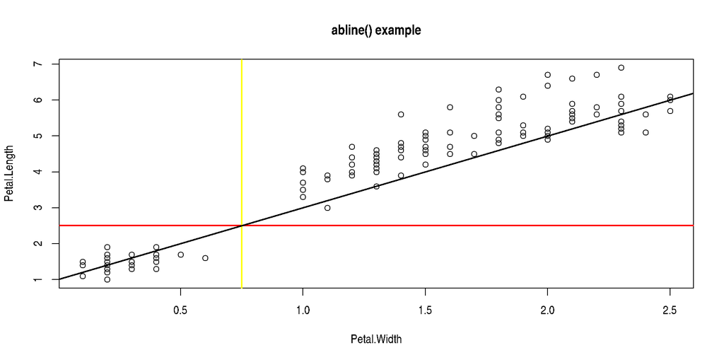

```r
## Initialize a plain x/y plot:
plot(Petal.Length ~ Petal.Width,
     data=iris,
     main = "abline() example"
     )

## Horizontal and vertical markers:
abline(h = 2.5, col = "red",
       lwd=2 ## line width
       )
abline(v = 0.75, col = "yellow", lwd=2)

## An "assumed" regression line for reference:
abline(a=1,b=2,lwd=2)
```

## R Plots (base) – **`layout()`**

Several plots can be combined on the same page in a **grid-like layout**.

The grid is **specified by a matrix of possible plot positions**, like so:

```r
## prepare the layout matrix
m <- matrix(1:4,
            nrow=2,
            ncol=2,
            byrow=FALSE)
m
```

```
     [,1] [,2]
[1,]    1    3
[2,]    2    4
```

The first plot will go to grid position 1, the second to position 2 … .

## R Plots (base) – **`layout()`**

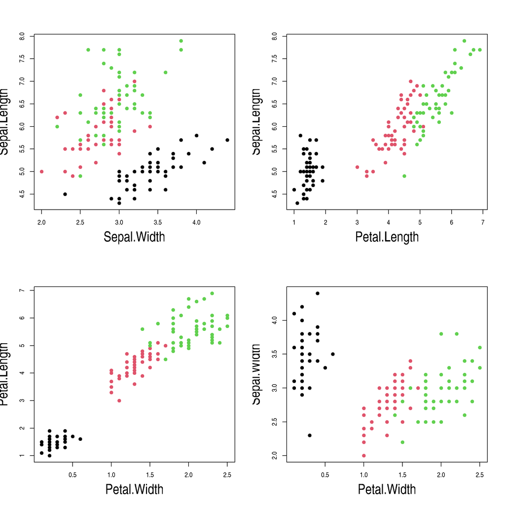

```r
layout(m) ## read the layout matrix

use_cols =  species_colors[iris$Species]
## 1
plot(Sepal.Length ~ Sepal.Width, data=iris,
     pch=21, col=use_cols, bg=use_cols,
     cex.lab=2)
## 2
plot(Petal.Length ~ Petal.Width, data=iris,
     pch=21, col=use_cols, bg=use_cols,
     cex.lab=2)
## 3
plot(Sepal.Length ~ Petal.Length, data=iris,
     pch=21, col=use_cols, bg=use_cols,
     cex.lab=2)
## 4
plot(Sepal.Width ~ Petal.Width, data=iris,
     pch=21, col=use_cols, bg=use_cols,
     cex.lab=2)
```

```r
layout(1) ## back to full screen
```

## R Plots (base) – **`hist()`**

The **hist()** function is one of those “dual use functions”:

With **add=FALSE**, it initializes the device and the coordinate system, while  
with **add=TRUE**, its output goes directly to an existing plot.

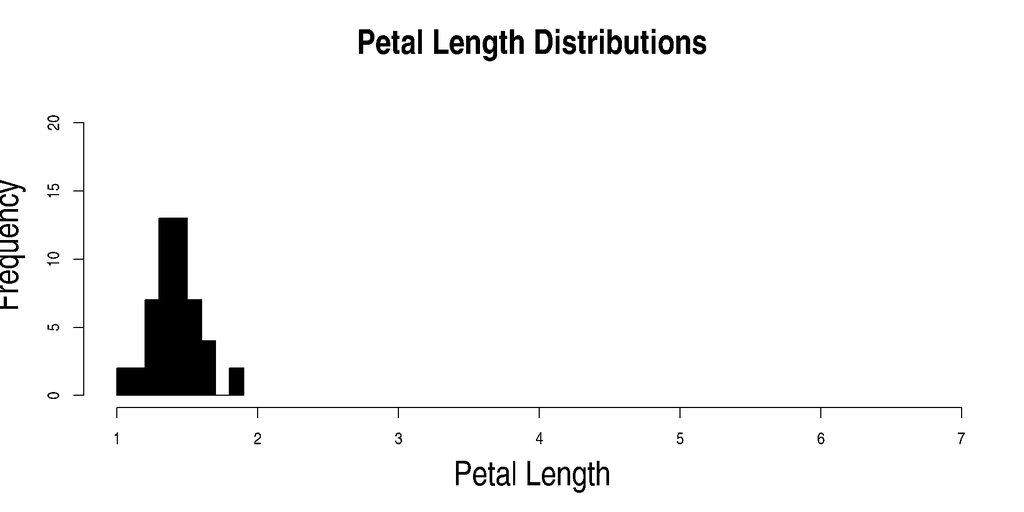

```r
setosa <- subset(iris,Species=="setosa")
versicolor <- subset(iris,Species=="versicolor")
virginica <- subset(iris,Species=="virginica")

## Plot the histogram of setosa,
## and initialize the entire plot:

hist(setosa$Petal.Length,
     col=species_colors["setosa"],

     add=FALSE, ## this is the default

     ## initialize to full x range !
     xlim=range(iris$Petal.Length),

     ## full y range you usually
     ## only know after some trials ..
     ylim=c(0,22),

     ## x-axis label
     xlab="Petal Length",

     ## larger axis labels:
     cex.lab = 2,

     main = "Petal Length Distributions",

     ## larger title:
     cex.main = 2
)
```

## R Plots (base) – **`hist()`**

The **hist()** function is one of those “dual use functions”:

With **add=FALSE**, it initializes the device and the coordinate system, while  
with **add=TRUE**, its output goes directly to an existing plot.

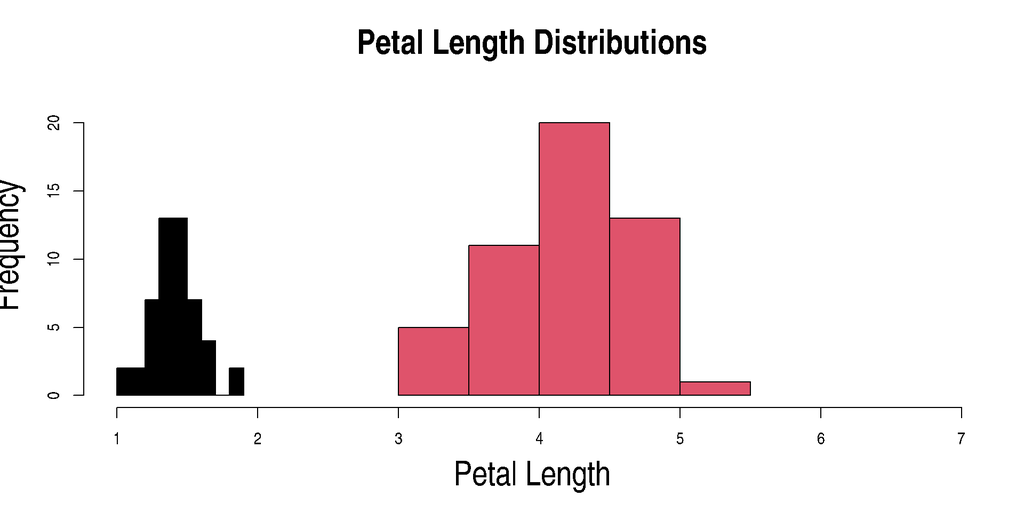

```r
hist(versicolor$Petal.Length,
     add=TRUE,
     col=species_colors["versicolor"]
)
```

## R Plots (base) – **`hist()`**

The **hist()** function is one of those “dual use functions”:

With **add=FALSE**, it initializes the device and the coordinate system, while  
with **add=TRUE**, its output goes directly to an existing plot.

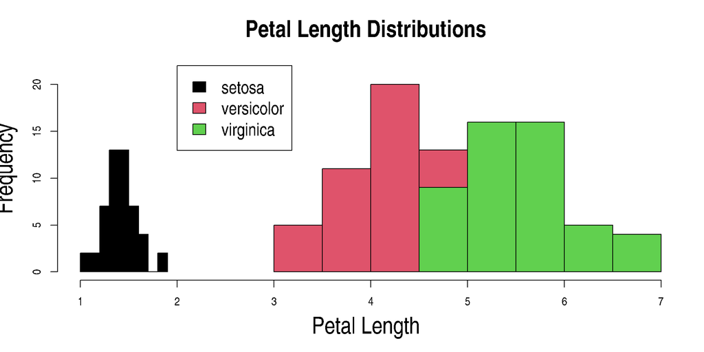

```r
hist(virginica$Petal.Length,
     add=TRUE,
     col=species_colors["virginica"]
)

legend(x=2,y=22,
       legend=c("setosa",
                "versicolor",
                "virginica"),
       fill=species_colors,
       cex =1.5, ## larger script in legend
       )
```

## R Plots (base) – **`boxplot()`**

The **boxplot()** function has **“dual-use”** capabilities, too.

However **it can accept a formula** with a factor on the right hand side, and it will **split the dataset automatically according to the factor levels**. So we can plot all species at once:

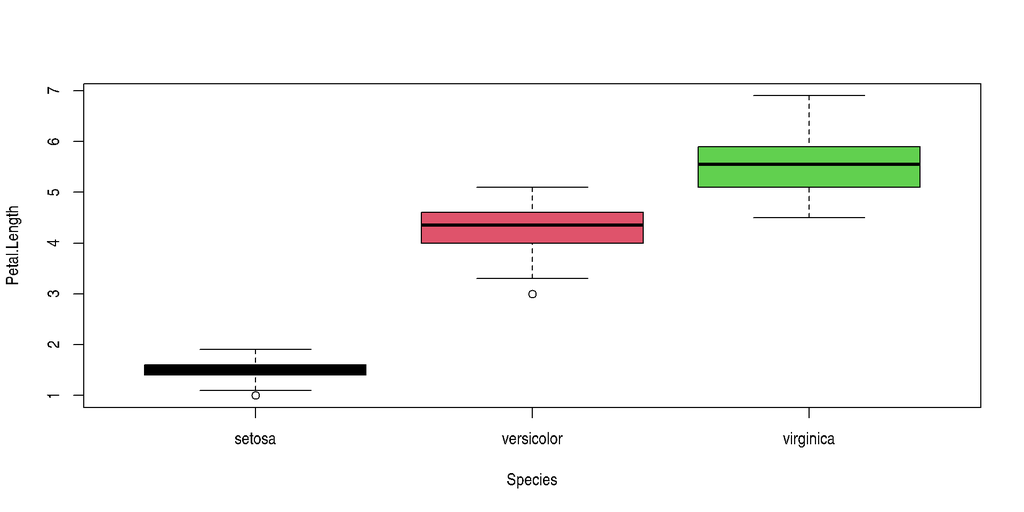

```r
boxplot(Petal.Length ~ Species,
        data = iris,
        ## colors are not automatically
        ## inferred from the factor levels!
        col = species_colors
        )
```

## R Plots (base) – **`boxplot()`**

Let’s **add a boxplot for the global Petal.Length distribution** (all species merged):

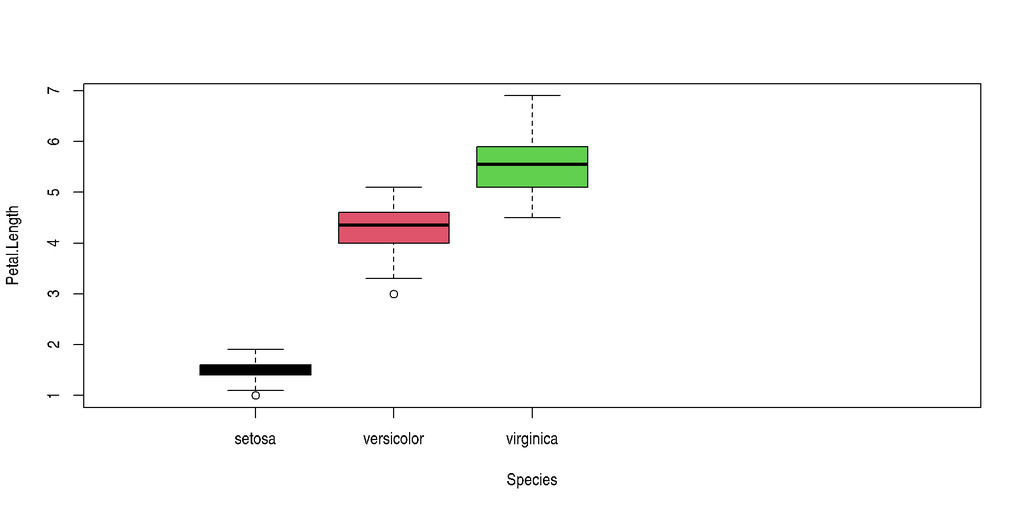

```r
# Repeat the last boxplot, with an extended x axis:
boxplot(Petal.Length ~ Species,
        data = iris, col = species_colors,
        xlim=c(0,6)
        )
```

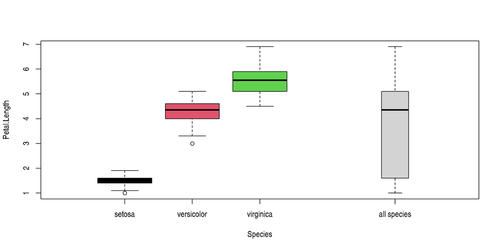

```r
boxplot(iris$Petal.Length, # take the entire column!
        add=TRUE,
        at=5, ## position on x axis
        names="all species",
        show.names=TRUE
        )
```

## R Plots (base) – **`Saving Plots From RStudio`**

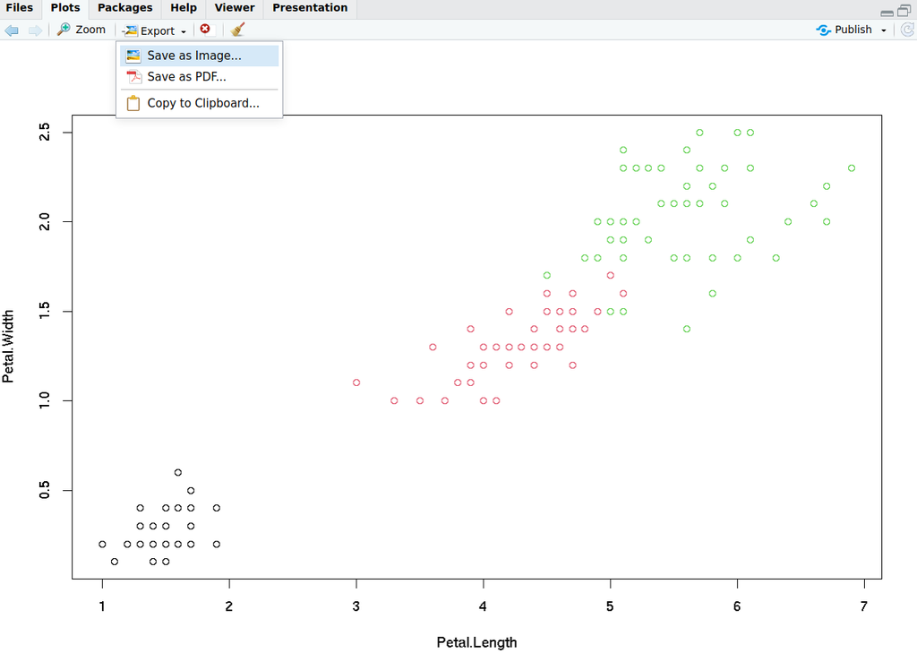

## R Plots (base) – **`Saving Plots From RStudio`**

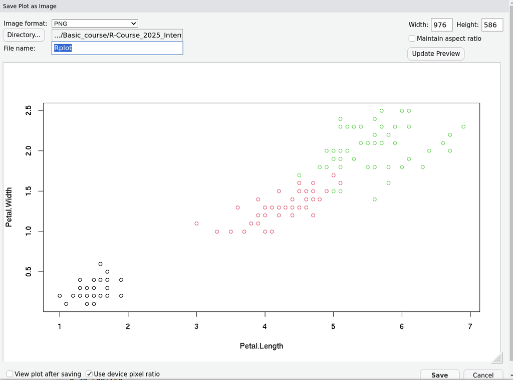

[figure not shown]